# Risk Factor Analysis

## Outcome Variable

**Outcome Variable:** whz

## Predictor Variables

**Intervention Variable:** hfoodsec

**Adjustment Set:**

- arm
- sex
- W_mage
- meducyrs
- feducyrs
- hhwealth_quart
- vagbrth
- W_nrooms
- W_nchldlt5
- brthmon
- W_parity
- impfloor
- impsan
- safeh20
- delta_W_mage
- delta_meducyrs
- delta_feducyrs
- delta_hhwealth_quart
- delta_vagbrth
- delta_W_nrooms
- delta_W_nchldlt5
- delta_brthmon
- delta_W_parity
- delta_impfloor
- delta_impsan
- delta_safeh20

## Stratifying Variables

The analysis was stratified on these variable(s):

- agecat
- studyid
- country

## Data Summary

| agecat | studyid | country | hfoodsec | n_cell | n |
| --- | --- | --- | --- | --- | --- |
| Birth | ki0047075b-MAL-ED | BANGLADESH | Food Secure | 138 | 162 |
| Birth | ki0047075b-MAL-ED | BANGLADESH | Mildly Food Insecure | 3 | 162 |
| Birth | ki0047075b-MAL-ED | BANGLADESH | Food Insecure | 21 | 162 |
| Birth | ki0047075b-MAL-ED | BRAZIL | Food Secure | 0 | 26 |
| Birth | ki0047075b-MAL-ED | BRAZIL | Mildly Food Insecure | 4 | 26 |
| Birth | ki0047075b-MAL-ED | BRAZIL | Food Insecure | 22 | 26 |
| Birth | ki0047075b-MAL-ED | INDIA | Food Secure | 32 | 35 |
| Birth | ki0047075b-MAL-ED | INDIA | Mildly Food Insecure | 1 | 35 |
| Birth | ki0047075b-MAL-ED | INDIA | Food Insecure | 2 | 35 |
| Birth | ki0047075b-MAL-ED | NEPAL | Food Secure | 10 | 14 |
| Birth | ki0047075b-MAL-ED | NEPAL | Mildly Food Insecure | 1 | 14 |
| Birth | ki0047075b-MAL-ED | NEPAL | Food Insecure | 3 | 14 |
| Birth | ki0047075b-MAL-ED | PERU | Food Secure | 23 | 89 |
| Birth | ki0047075b-MAL-ED | PERU | Mildly Food Insecure | 22 | 89 |
| Birth | ki0047075b-MAL-ED | PERU | Food Insecure | 44 | 89 |
| Birth | ki0047075b-MAL-ED | SOUTH AFRICA | Food Secure | 45 | 87 |
| Birth | ki0047075b-MAL-ED | SOUTH AFRICA | Mildly Food Insecure | 9 | 87 |
| Birth | ki0047075b-MAL-ED | SOUTH AFRICA | Food Insecure | 33 | 87 |
| Birth | ki1017093-NIH-Birth | BANGLADESH | Food Secure | 86 | 575 |
| Birth | ki1017093-NIH-Birth | BANGLADESH | Mildly Food Insecure | 453 | 575 |
| Birth | ki1017093-NIH-Birth | BANGLADESH | Food Insecure | 36 | 575 |
| Birth | ki1017093c-NIH-Crypto | BANGLADESH | Food Secure | 429 | 707 |
| Birth | ki1017093c-NIH-Crypto | BANGLADESH | Mildly Food Insecure | 199 | 707 |
| Birth | ki1017093c-NIH-Crypto | BANGLADESH | Food Insecure | 79 | 707 |
| Birth | ki1113344-GMS-Nepal | NEPAL | Food Secure | 442 | 620 |
| Birth | ki1113344-GMS-Nepal | NEPAL | Mildly Food Insecure | 100 | 620 |
| Birth | ki1113344-GMS-Nepal | NEPAL | Food Insecure | 78 | 620 |
| Birth | kiGH5241-JiVitA-3 | BANGLADESH | Food Secure | 7326 | 14320 |
| Birth | kiGH5241-JiVitA-3 | BANGLADESH | Mildly Food Insecure | 4693 | 14320 |
| Birth | kiGH5241-JiVitA-3 | BANGLADESH | Food Insecure | 2301 | 14320 |

[output cut: 69 more lines]

The following strata were considered:

- agecat: 24 months, studyid: ki0047075b-MAL-ED, country: BANGLADESH
- agecat: 24 months, studyid: ki0047075b-MAL-ED, country: BRAZIL
- agecat: 24 months, studyid: ki0047075b-MAL-ED, country: INDIA
- agecat: 24 months, studyid: ki0047075b-MAL-ED, country: NEPAL
- agecat: 24 months, studyid: ki0047075b-MAL-ED, country: PERU
- agecat: 24 months, studyid: ki0047075b-MAL-ED, country: SOUTH AFRICA
- agecat: 24 months, studyid: ki1017093-NIH-Birth, country: BANGLADESH
- agecat: 24 months, studyid: ki1017093c-NIH-Crypto, country: BANGLADESH
- agecat: 24 months, studyid: ki1113344-GMS-Nepal, country: NEPAL
- agecat: 24 months, studyid: kiGH5241-JiVitA-3, country: BANGLADESH
- agecat: 24 months, studyid: kiGH5241-JiVitA-4, country: BANGLADESH
- agecat: 6 months, studyid: ki0047075b-MAL-ED, country: BANGLADESH
- agecat: 6 months, studyid: ki0047075b-MAL-ED, country: BRAZIL
- agecat: 6 months, studyid: ki0047075b-MAL-ED, country: INDIA
- agecat: 6 months, studyid: ki0047075b-MAL-ED, country: NEPAL
- agecat: 6 months, studyid: ki0047075b-MAL-ED, country: PERU
- agecat: 6 months, studyid: ki0047075b-MAL-ED, country: SOUTH AFRICA
- agecat: 6 months, studyid: ki1017093-NIH-Birth, country: BANGLADESH
- agecat: 6 months, studyid: ki1017093c-NIH-Crypto, country: BANGLADESH
- agecat: 6 months, studyid: ki1113344-GMS-Nepal, country: NEPAL
- agecat: 6 months, studyid: kiGH5241-JiVitA-3, country: BANGLADESH
- agecat: 6 months, studyid: kiGH5241-JiVitA-4, country: BANGLADESH
- agecat: Birth, studyid: ki0047075b-MAL-ED, country: BANGLADESH
- agecat: Birth, studyid: ki0047075b-MAL-ED, country: BRAZIL
- agecat: Birth, studyid: ki0047075b-MAL-ED, country: INDIA
- agecat: Birth, studyid: ki0047075b-MAL-ED, country: NEPAL
- agecat: Birth, studyid: ki0047075b-MAL-ED, country: PERU
- agecat: Birth, studyid: ki0047075b-MAL-ED, country: SOUTH AFRICA
- agecat: Birth, studyid: ki1017093-NIH-Birth, country: BANGLADESH
- agecat: Birth, studyid: ki1017093c-NIH-Crypto, country: BANGLADESH
- agecat: Birth, studyid: ki1113344-GMS-Nepal, country: NEPAL
- agecat: Birth, studyid: kiGH5241-JiVitA-3, country: BANGLADESH
- agecat: Birth, studyid: kiGH5241-JiVitA-4, country: BANGLADESH

### Dropped Strata

Some strata were dropped due to rare outcomes:

- agecat: Birth, studyid: ki0047075b-MAL-ED, country: BANGLADESH
- agecat: Birth, studyid: ki0047075b-MAL-ED, country: BRAZIL
- agecat: Birth, studyid: ki0047075b-MAL-ED, country: INDIA
- agecat: Birth, studyid: ki0047075b-MAL-ED, country: NEPAL
- agecat: 6 months, studyid: ki0047075b-MAL-ED, country: BANGLADESH
- agecat: 6 months, studyid: ki0047075b-MAL-ED, country: BRAZIL
- agecat: 24 months, studyid: ki0047075b-MAL-ED, country: BANGLADESH
- agecat: 24 months, studyid: ki0047075b-MAL-ED, country: BRAZIL

## Methods Detail

We’re interested in the causal parameters $E[Y_a]$ for all values of $a \in \mathcal{A}$. These parameters represent the mean outcome if, possibly contrary to fact, we intervened to set all units to have $A=a$. Under the randomization and positivity assumptions, these are identified by the statistical parameters $\psi_a=E_W[E_{Y|A,W}(Y|A=a,W)]$. In addition, we’re interested in the mean of $Y$, $E[Y]$ under no intervention (the observed mean). We will estimate these parameters by using SuperLearner to fit the relevant likelihood factors – $E_{Y|A,W}(Y|A=a,W)$ and $p(A=a|W)$, and then updating our likelihood fit using a joint TMLE.

For unadjusted analyses ($W=\{\}$), initial likelihoods were estimated using Lrnr_glm to estimate the simple $E(Y|A)$ and Lrnr_mean to estimate $p(A)$. For adjusted analyses, a small library containing Lrnr_glmnet, Lrnr_xgboost, and Lrnr_mean was used.

Having estimated these parameters, we will then use the delta method to estimate relative risks and attributable risks relative to a prespecified baseline level of $A$.

# Results Detail

## Results Plots

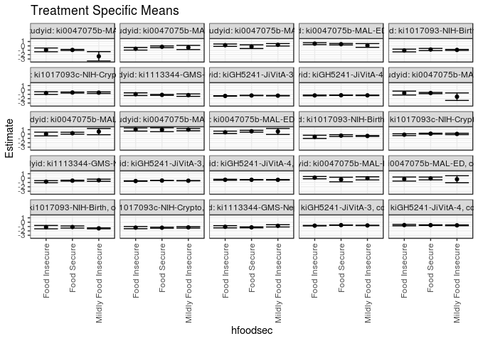

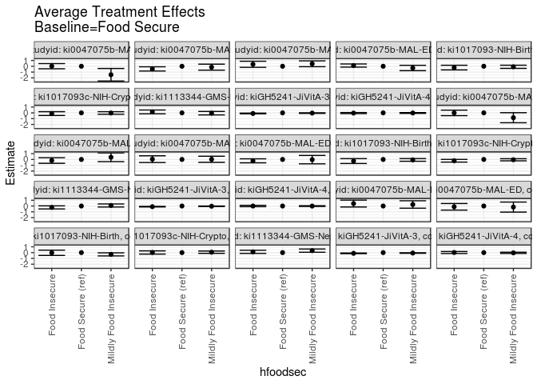

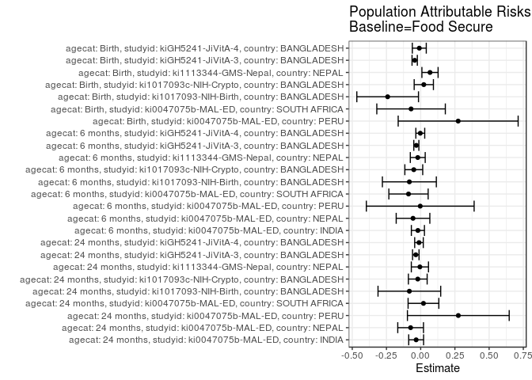

## Results Table

### Parameter: TSM

| agecat | studyid | country | intervention_level | baseline_level | estimate | ci_lower | ci_upper |
| --- | --- | --- | --- | --- | --- | --- | --- |
| Birth | ki0047075b-MAL-ED | PERU | Food Secure | NA | -0.3222093 | -0.8473125 | 0.2028939 |
| Birth | ki0047075b-MAL-ED | PERU | Mildly Food Insecure | NA | -0.0553676 | -0.4115934 | 0.3008581 |
| Birth | ki0047075b-MAL-ED | PERU | Food Insecure | NA | 0.1044110 | -0.1629824 | 0.3718044 |
| Birth | ki0047075b-MAL-ED | SOUTH AFRICA | Food Secure | NA | -0.0800000 | -0.4003913 | 0.2403913 |
| Birth | ki0047075b-MAL-ED | SOUTH AFRICA | Mildly Food Insecure | NA | -0.2611111 | -1.0678216 | 0.5455994 |
| Birth | ki0047075b-MAL-ED | SOUTH AFRICA | Food Insecure | NA | -0.2157576 | -0.6840291 | 0.2525139 |
| Birth | ki1017093-NIH-Birth | BANGLADESH | Food Secure | NA | -1.1086012 | -1.3516051 | -0.8655974 |
| Birth | ki1017093-NIH-Birth | BANGLADESH | Mildly Food Insecure | NA | -1.4131658 | -1.5200131 | -1.3063186 |
| Birth | ki1017093-NIH-Birth | BANGLADESH | Food Insecure | NA | -1.1405914 | -1.5222777 | -0.7589051 |
| Birth | ki1017093c-NIH-Crypto | BANGLADESH | Food Secure | NA | -1.2669383 | -1.3783719 | -1.1555048 |
| Birth | ki1017093c-NIH-Crypto | BANGLADESH | Mildly Food Insecure | NA | -1.1957481 | -1.3599304 | -1.0315659 |
| Birth | ki1017093c-NIH-Crypto | BANGLADESH | Food Insecure | NA | -1.2455993 | -1.4969294 | -0.9942691 |
| Birth | ki1113344-GMS-Nepal | NEPAL | Food Secure | NA | -1.1846189 | -1.2887291 | -1.0805086 |
| Birth | ki1113344-GMS-Nepal | NEPAL | Mildly Food Insecure | NA | -0.8412872 | -1.1020239 | -0.5805504 |
| Birth | ki1113344-GMS-Nepal | NEPAL | Food Insecure | NA | -1.0539829 | -1.3044336 | -0.8035321 |
| Birth | kiGH5241-JiVitA-3 | BANGLADESH | Food Secure | NA | -0.6770392 | -0.7056800 | -0.6483984 |
| Birth | kiGH5241-JiVitA-3 | BANGLADESH | Mildly Food Insecure | NA | -0.7497460 | -0.7858019 | -0.7136901 |
| Birth | kiGH5241-JiVitA-3 | BANGLADESH | Food Insecure | NA | -0.7999574 | -0.8510995 | -0.7488154 |
| Birth | kiGH5241-JiVitA-4 | BANGLADESH | Food Secure | NA | -0.6796699 | -0.7467365 | -0.6126033 |
| Birth | kiGH5241-JiVitA-4 | BANGLADESH | Mildly Food Insecure | NA | -0.7199734 | -0.8087480 | -0.6311988 |
| Birth | kiGH5241-JiVitA-4 | BANGLADESH | Food Insecure | NA | -0.6618633 | -0.8220325 | -0.5016941 |
| 6 months | ki0047075b-MAL-ED | INDIA | Food Secure | NA | -0.7024474 | -0.8452279 | -0.5596668 |
| 6 months | ki0047075b-MAL-ED | INDIA | Mildly Food Insecure | NA | -1.5420000 | -2.3989104 | -0.6850896 |
| 6 months | ki0047075b-MAL-ED | INDIA | Food Insecure | NA | -0.7090196 | -1.1598311 | -0.2582081 |
| 6 months | ki0047075b-MAL-ED | NEPAL | Food Secure | NA | 0.1848840 | -0.0361491 | 0.4059170 |
| 6 months | ki0047075b-MAL-ED | NEPAL | Mildly Food Insecure | NA | 0.5622262 | -0.1561011 | 1.2805534 |
| 6 months | ki0047075b-MAL-ED | NEPAL | Food Insecure | NA | -0.0004700 | -0.4279698 | 0.4270298 |
| 6 months | ki0047075b-MAL-ED | PERU | Food Secure | NA | 0.9872983 | 0.5406661 | 1.4339304 |
| 6 months | ki0047075b-MAL-ED | PERU | Mildly Food Insecure | NA | 1.0136333 | 0.7387277 | 1.2885388 |
| 6 months | ki0047075b-MAL-ED | PERU | Food Insecure | NA | 1.0357346 | 0.6730268 | 1.3984425 |
| 6 months | ki0047075b-MAL-ED | SOUTH AFRICA | Food Secure | NA | 0.6319059 | 0.4158069 | 0.8480048 |
| 6 months | ki0047075b-MAL-ED | SOUTH AFRICA | Mildly Food Insecure | NA | 0.5998791 | -0.0890815 | 1.2888398 |
| 6 months | ki0047075b-MAL-ED | SOUTH AFRICA | Food Insecure | NA | 0.3946807 | 0.1221908 | 0.6671706 |
| 6 months | ki1017093-NIH-Birth | BANGLADESH | Food Secure | NA | -0.3646986 | -0.5703113 | -0.1590860 |
| 6 months | ki1017093-NIH-Birth | BANGLADESH | Mildly Food Insecure | NA | -0.4428837 | -0.5478620 | -0.3379053 |
| 6 months | ki1017093-NIH-Birth | BANGLADESH | Food Insecure | NA | -0.6411366 | -1.0084460 | -0.2738272 |
| 6 months | ki1017093c-NIH-Crypto | BANGLADESH | Food Secure | NA | 0.0801745 | -0.0252724 | 0.1856214 |
| 6 months | ki1017093c-NIH-Crypto | BANGLADESH | Mildly Food Insecure | NA | 0.0258116 | -0.1273137 | 0.1789370 |
| 6 months | ki1017093c-NIH-Crypto | BANGLADESH | Food Insecure | NA | -0.1443824 | -0.3516956 | 0.0629307 |
| 6 months | ki1113344-GMS-Nepal | NEPAL | Food Secure | NA | -0.5805701 | -0.6867198 | -0.4744205 |
| 6 months | ki1113344-GMS-Nepal | NEPAL | Mildly Food Insecure | NA | -0.4908326 | -0.7306410 | -0.2510243 |
| 6 months | ki1113344-GMS-Nepal | NEPAL | Food Insecure | NA | -0.8170061 | -1.0602091 | -0.5738032 |
| 6 months | kiGH5241-JiVitA-3 | BANGLADESH | Food Secure | NA | -0.5609366 | -0.5883975 | -0.5334756 |
| 6 months | kiGH5241-JiVitA-3 | BANGLADESH | Mildly Food Insecure | NA | -0.5991974 | -0.6303040 | -0.5680908 |
| 6 months | kiGH5241-JiVitA-3 | BANGLADESH | Food Insecure | NA | -0.6717470 | -0.7198284 | -0.6236655 |
| 6 months | kiGH5241-JiVitA-4 | BANGLADESH | Food Secure | NA | -0.3866459 | -0.4352719 | -0.3380198 |
| 6 months | kiGH5241-JiVitA-4 | BANGLADESH | Mildly Food Insecure | NA | -0.3963283 | -0.4545087 | -0.3381479 |
| 6 months | kiGH5241-JiVitA-4 | BANGLADESH | Food Insecure | NA | -0.3847152 | -0.4959977 | -0.2734328 |
| 24 months | ki0047075b-MAL-ED | INDIA | Food Secure | NA | -0.9263947 | -1.0447734 | -0.8080160 |
| 24 months | ki0047075b-MAL-ED | INDIA | Mildly Food Insecure | NA | -2.3840000 | -3.4554070 | -1.3125930 |
| 24 months | ki0047075b-MAL-ED | INDIA | Food Insecure | NA | -0.9111765 | -1.3418053 | -0.4805476 |
| 24 months | ki0047075b-MAL-ED | NEPAL | Food Secure | NA | -0.2022599 | -0.4012914 | -0.0032285 |
| 24 months | ki0047075b-MAL-ED | NEPAL | Mildly Food Insecure | NA | -0.3567670 | -0.8374285 | 0.1238946 |
| 24 months | ki0047075b-MAL-ED | NEPAL | Food Insecure | NA | -0.6585963 | -0.9620612 | -0.3551314 |
| 24 months | ki0047075b-MAL-ED | PERU | Food Secure | NA | -0.1759578 | -0.6045121 | 0.2525965 |
| 24 months | ki0047075b-MAL-ED | PERU | Mildly Food Insecure | NA | 0.2523339 | -0.0245878 | 0.5292555 |
| 24 months | ki0047075b-MAL-ED | PERU | Food Insecure | NA | 0.1626072 | -0.1135871 | 0.4388015 |
| 24 months | ki0047075b-MAL-ED | SOUTH AFRICA | Food Secure | NA | 0.3937792 | 0.2256341 | 0.5619243 |
| 24 months | ki0047075b-MAL-ED | SOUTH AFRICA | Mildly Food Insecure | NA | 0.0967813 | -0.3321524 | 0.5257150 |
| 24 months | ki0047075b-MAL-ED | SOUTH AFRICA | Food Insecure | NA | 0.5175993 | 0.3031173 | 0.7320813 |
| 24 months | ki1017093-NIH-Birth | BANGLADESH | Food Secure | NA | -0.8288446 | -1.0755897 | -0.5820995 |
| 24 months | ki1017093-NIH-Birth | BANGLADESH | Mildly Food Insecure | NA | -0.9183189 | -1.0324116 | -0.8042262 |
| 24 months | ki1017093-NIH-Birth | BANGLADESH | Food Insecure | NA | -1.0568944 | -1.3738660 | -0.7399227 |
| 24 months | ki1017093c-NIH-Crypto | BANGLADESH | Food Secure | NA | -0.5891303 | -0.7139447 | -0.4643159 |
| 24 months | ki1017093c-NIH-Crypto | BANGLADESH | Mildly Food Insecure | NA | -0.6140311 | -0.7973530 | -0.4307092 |
| 24 months | ki1017093c-NIH-Crypto | BANGLADESH | Food Insecure | NA | -0.7122863 | -1.0151371 | -0.4094356 |
| 24 months | ki1113344-GMS-Nepal | NEPAL | Food Secure | NA | -1.1248394 | -1.2313751 | -1.0183038 |
| 24 months | ki1113344-GMS-Nepal | NEPAL | Mildly Food Insecure | NA | -1.1801829 | -1.4579488 | -0.9024171 |
| 24 months | ki1113344-GMS-Nepal | NEPAL | Food Insecure | NA | -0.9644722 | -1.2751810 | -0.6537633 |
| 24 months | kiGH5241-JiVitA-3 | BANGLADESH | Food Secure | NA | -1.2645843 | -1.2975883 | -1.2315803 |
| 24 months | kiGH5241-JiVitA-3 | BANGLADESH | Mildly Food Insecure | NA | -1.3033986 | -1.3454470 | -1.2613503 |
| 24 months | kiGH5241-JiVitA-3 | BANGLADESH | Food Insecure | NA | -1.3725501 | -1.4259074 | -1.3191927 |
| 24 months | kiGH5241-JiVitA-4 | BANGLADESH | Food Secure | NA | -1.2119538 | -1.2565893 | -1.1673182 |
| 24 months | kiGH5241-JiVitA-4 | BANGLADESH | Mildly Food Insecure | NA | -1.2335258 | -1.2891721 | -1.1778794 |
| 24 months | kiGH5241-JiVitA-4 | BANGLADESH | Food Insecure | NA | -1.2480299 | -1.3285577 | -1.1675022 |

### Parameter: E(Y)

| agecat | studyid | country | intervention_level | baseline_level | estimate | ci_lower | ci_upper |
| --- | --- | --- | --- | --- | --- | --- | --- |
| Birth | ki0047075b-MAL-ED | PERU | NA | NA | -0.0483146 | -0.2475806 | 0.1509514 |
| Birth | ki0047075b-MAL-ED | SOUTH AFRICA | NA | NA | -0.1502299 | -0.4075620 | 0.1071022 |
| Birth | ki1017093-NIH-Birth | BANGLADESH | NA | NA | -1.3499217 | -1.4444634 | -1.2553801 |
| Birth | ki1017093c-NIH-Crypto | BANGLADESH | NA | NA | -1.2441513 | -1.3281130 | -1.1601897 |
| Birth | ki1113344-GMS-Nepal | NEPAL | NA | NA | -1.1165161 | -1.2055683 | -1.0274639 |
| Birth | kiGH5241-JiVitA-3 | BANGLADESH | NA | NA | -0.7208547 | -0.7418118 | -0.6998977 |
| Birth | kiGH5241-JiVitA-4 | BANGLADESH | NA | NA | -0.6898154 | -0.7422632 | -0.6373675 |
| 6 months | ki0047075b-MAL-ED | INDIA | NA | NA | -0.7227752 | -0.8585532 | -0.5869972 |
| 6 months | ki0047075b-MAL-ED | NEPAL | NA | NA | 0.1289063 | -0.0638567 | 0.3216692 |
| 6 months | ki0047075b-MAL-ED | PERU | NA | NA | 0.9840541 | 0.7695460 | 1.1985621 |
| 6 months | ki0047075b-MAL-ED | SOUTH AFRICA | NA | NA | 0.5429678 | 0.3813968 | 0.7045389 |
| 6 months | ki1017093-NIH-Birth | BANGLADESH | NA | NA | -0.4474038 | -0.5378167 | -0.3569909 |
| 6 months | ki1017093c-NIH-Crypto | BANGLADESH | NA | NA | 0.0297622 | -0.0491685 | 0.1086930 |
| 6 months | ki1113344-GMS-Nepal | NEPAL | NA | NA | -0.6018803 | -0.6892284 | -0.5145323 |
| 6 months | kiGH5241-JiVitA-3 | BANGLADESH | NA | NA | -0.5927331 | -0.6123184 | -0.5731479 |
| 6 months | kiGH5241-JiVitA-4 | BANGLADESH | NA | NA | -0.3895527 | -0.4270314 | -0.3520739 |
| 24 months | ki0047075b-MAL-ED | INDIA | NA | NA | -0.9595519 | -1.0781202 | -0.8409836 |
| 24 months | ki0047075b-MAL-ED | NEPAL | NA | NA | -0.2757812 | -0.4379560 | -0.1136065 |
| 24 months | ki0047075b-MAL-ED | PERU | NA | NA | 0.0990187 | -0.0788709 | 0.2769082 |
| 24 months | ki0047075b-MAL-ED | SOUTH AFRICA | NA | NA | 0.4141009 | 0.2892188 | 0.5389829 |
| 24 months | ki1017093-NIH-Birth | BANGLADESH | NA | NA | -0.9115790 | -1.0095022 | -0.8136559 |
| 24 months | ki1017093c-NIH-Crypto | BANGLADESH | NA | NA | -0.6103502 | -0.7050157 | -0.5156847 |
| 24 months | ki1113344-GMS-Nepal | NEPAL | NA | NA | -1.1304997 | -1.2205265 | -1.0404728 |
| 24 months | kiGH5241-JiVitA-3 | BANGLADESH | NA | NA | -1.3003702 | -1.3240616 | -1.2766787 |
| 24 months | kiGH5241-JiVitA-4 | BANGLADESH | NA | NA | -1.2243590 | -1.2566569 | -1.1920612 |

### Parameter: ATE

| agecat | studyid | country | intervention_level | baseline_level | estimate | ci_lower | ci_upper |
| --- | --- | --- | --- | --- | --- | --- | --- |
| Birth | ki0047075b-MAL-ED | PERU | Food Secure | Food Secure | 0.0000000 | 0.0000000 | 0.0000000 |
| Birth | ki0047075b-MAL-ED | PERU | Mildly Food Insecure | Food Secure | 0.2668417 | -0.3725440 | 0.9062274 |
| Birth | ki0047075b-MAL-ED | PERU | Food Insecure | Food Secure | 0.4266203 | -0.1644276 | 1.0176683 |
| Birth | ki0047075b-MAL-ED | SOUTH AFRICA | Food Secure | Food Secure | 0.0000000 | 0.0000000 | 0.0000000 |
| Birth | ki0047075b-MAL-ED | SOUTH AFRICA | Mildly Food Insecure | Food Secure | -0.1811111 | -1.0491159 | 0.6868937 |
| Birth | ki0047075b-MAL-ED | SOUTH AFRICA | Food Insecure | Food Secure | -0.1357576 | -0.7031452 | 0.4316301 |
| Birth | ki1017093-NIH-Birth | BANGLADESH | Food Secure | Food Secure | 0.0000000 | 0.0000000 | 0.0000000 |
| Birth | ki1017093-NIH-Birth | BANGLADESH | Mildly Food Insecure | Food Secure | -0.3045646 | -0.5700559 | -0.0390732 |
| Birth | ki1017093-NIH-Birth | BANGLADESH | Food Insecure | Food Secure | -0.0319902 | -0.4843898 | 0.4204095 |
| Birth | ki1017093c-NIH-Crypto | BANGLADESH | Food Secure | Food Secure | 0.0000000 | 0.0000000 | 0.0000000 |
| Birth | ki1017093c-NIH-Crypto | BANGLADESH | Mildly Food Insecure | Food Secure | 0.0711902 | -0.1276289 | 0.2700093 |
| Birth | ki1017093c-NIH-Crypto | BANGLADESH | Food Insecure | Food Secure | 0.0213391 | -0.2540476 | 0.2967258 |
| Birth | ki1113344-GMS-Nepal | NEPAL | Food Secure | Food Secure | 0.0000000 | 0.0000000 | 0.0000000 |
| Birth | ki1113344-GMS-Nepal | NEPAL | Mildly Food Insecure | Food Secure | 0.3433317 | 0.0630348 | 0.6236287 |
| Birth | ki1113344-GMS-Nepal | NEPAL | Food Insecure | Food Secure | 0.1306360 | -0.1398800 | 0.4011520 |
| Birth | kiGH5241-JiVitA-3 | BANGLADESH | Food Secure | Food Secure | 0.0000000 | 0.0000000 | 0.0000000 |
| Birth | kiGH5241-JiVitA-3 | BANGLADESH | Mildly Food Insecure | Food Secure | -0.0727068 | -0.1167421 | -0.0286714 |
| Birth | kiGH5241-JiVitA-3 | BANGLADESH | Food Insecure | Food Secure | -0.1229182 | -0.1794982 | -0.0663382 |
| Birth | kiGH5241-JiVitA-4 | BANGLADESH | Food Secure | Food Secure | 0.0000000 | 0.0000000 | 0.0000000 |
| Birth | kiGH5241-JiVitA-4 | BANGLADESH | Mildly Food Insecure | Food Secure | -0.0403035 | -0.1505844 | 0.0699774 |
| Birth | kiGH5241-JiVitA-4 | BANGLADESH | Food Insecure | Food Secure | 0.0178066 | -0.1551103 | 0.1907235 |
| 6 months | ki0047075b-MAL-ED | INDIA | Food Secure | Food Secure | 0.0000000 | 0.0000000 | 0.0000000 |
| 6 months | ki0047075b-MAL-ED | INDIA | Mildly Food Insecure | Food Secure | -0.8395526 | -1.7082768 | 0.0291715 |
| 6 months | ki0047075b-MAL-ED | INDIA | Food Insecure | Food Secure | -0.0065722 | -0.4794542 | 0.4663097 |
| 6 months | ki0047075b-MAL-ED | NEPAL | Food Secure | Food Secure | 0.0000000 | 0.0000000 | 0.0000000 |
| 6 months | ki0047075b-MAL-ED | NEPAL | Mildly Food Insecure | Food Secure | 0.3773422 | -0.3767447 | 1.1314291 |
| 6 months | ki0047075b-MAL-ED | NEPAL | Food Insecure | Food Secure | -0.1853540 | -0.6663212 | 0.2956132 |
| 6 months | ki0047075b-MAL-ED | PERU | Food Secure | Food Secure | 0.0000000 | 0.0000000 | 0.0000000 |
| 6 months | ki0047075b-MAL-ED | PERU | Mildly Food Insecure | Food Secure | 0.0263350 | -0.5024500 | 0.5551200 |
| 6 months | ki0047075b-MAL-ED | PERU | Food Insecure | Food Secure | 0.0484363 | -0.5317492 | 0.6286219 |
| 6 months | ki0047075b-MAL-ED | SOUTH AFRICA | Food Secure | Food Secure | 0.0000000 | 0.0000000 | 0.0000000 |
| 6 months | ki0047075b-MAL-ED | SOUTH AFRICA | Mildly Food Insecure | Food Secure | -0.0320268 | -0.7536283 | 0.6895748 |
| 6 months | ki0047075b-MAL-ED | SOUTH AFRICA | Food Insecure | Food Secure | -0.2372251 | -0.5854478 | 0.1109976 |
| 6 months | ki1017093-NIH-Birth | BANGLADESH | Food Secure | Food Secure | 0.0000000 | 0.0000000 | 0.0000000 |
| 6 months | ki1017093-NIH-Birth | BANGLADESH | Mildly Food Insecure | Food Secure | -0.0781850 | -0.3100103 | 0.1536402 |
| 6 months | ki1017093-NIH-Birth | BANGLADESH | Food Insecure | Food Secure | -0.2764380 | -0.6982839 | 0.1454080 |
| 6 months | ki1017093c-NIH-Crypto | BANGLADESH | Food Secure | Food Secure | 0.0000000 | 0.0000000 | 0.0000000 |
| 6 months | ki1017093c-NIH-Crypto | BANGLADESH | Mildly Food Insecure | Food Secure | -0.0543629 | -0.2402711 | 0.1315453 |
| 6 months | ki1017093c-NIH-Crypto | BANGLADESH | Food Insecure | Food Secure | -0.2245569 | -0.4574542 | 0.0083403 |
| 6 months | ki1113344-GMS-Nepal | NEPAL | Food Secure | Food Secure | 0.0000000 | 0.0000000 | 0.0000000 |
| 6 months | ki1113344-GMS-Nepal | NEPAL | Mildly Food Insecure | Food Secure | 0.0897375 | -0.1726423 | 0.3521173 |
| 6 months | ki1113344-GMS-Nepal | NEPAL | Food Insecure | Food Secure | -0.2364360 | -0.5019724 | 0.0291005 |
| 6 months | kiGH5241-JiVitA-3 | BANGLADESH | Food Secure | Food Secure | 0.0000000 | 0.0000000 | 0.0000000 |
| 6 months | kiGH5241-JiVitA-3 | BANGLADESH | Mildly Food Insecure | Food Secure | -0.0382608 | -0.0790872 | 0.0025657 |
| 6 months | kiGH5241-JiVitA-3 | BANGLADESH | Food Insecure | Food Secure | -0.1108104 | -0.1642108 | -0.0574099 |
| 6 months | kiGH5241-JiVitA-4 | BANGLADESH | Food Secure | Food Secure | 0.0000000 | 0.0000000 | 0.0000000 |
| 6 months | kiGH5241-JiVitA-4 | BANGLADESH | Mildly Food Insecure | Food Secure | -0.0096824 | -0.0813172 | 0.0619524 |
| 6 months | kiGH5241-JiVitA-4 | BANGLADESH | Food Insecure | Food Secure | 0.0019306 | -0.1163289 | 0.1201902 |
| 24 months | ki0047075b-MAL-ED | INDIA | Food Secure | Food Secure | 0.0000000 | 0.0000000 | 0.0000000 |
| 24 months | ki0047075b-MAL-ED | INDIA | Mildly Food Insecure | Food Secure | -1.4576053 | -2.5355322 | -0.3796783 |
| 24 months | ki0047075b-MAL-ED | INDIA | Food Insecure | Food Secure | 0.0152183 | -0.4313853 | 0.4618218 |
| 24 months | ki0047075b-MAL-ED | NEPAL | Food Secure | Food Secure | 0.0000000 | 0.0000000 | 0.0000000 |
| 24 months | ki0047075b-MAL-ED | NEPAL | Mildly Food Insecure | Food Secure | -0.1545070 | -0.6734597 | 0.3644457 |
| 24 months | ki0047075b-MAL-ED | NEPAL | Food Insecure | Food Secure | -0.4563364 | -0.8191384 | -0.0935344 |
| 24 months | ki0047075b-MAL-ED | PERU | Food Secure | Food Secure | 0.0000000 | 0.0000000 | 0.0000000 |
| 24 months | ki0047075b-MAL-ED | PERU | Mildly Food Insecure | Food Secure | 0.4282917 | -0.0726838 | 0.9292673 |
| 24 months | ki0047075b-MAL-ED | PERU | Food Insecure | Food Secure | 0.3385650 | -0.1858552 | 0.8629852 |
| 24 months | ki0047075b-MAL-ED | SOUTH AFRICA | Food Secure | Food Secure | 0.0000000 | 0.0000000 | 0.0000000 |
| 24 months | ki0047075b-MAL-ED | SOUTH AFRICA | Mildly Food Insecure | Food Secure | -0.2969979 | -0.7575957 | 0.1635998 |
| 24 months | ki0047075b-MAL-ED | SOUTH AFRICA | Food Insecure | Food Secure | 0.1238201 | -0.1487144 | 0.3963545 |
| 24 months | ki1017093-NIH-Birth | BANGLADESH | Food Secure | Food Secure | 0.0000000 | 0.0000000 | 0.0000000 |
| 24 months | ki1017093-NIH-Birth | BANGLADESH | Mildly Food Insecure | Food Secure | -0.0894743 | -0.3626427 | 0.1836941 |
| 24 months | ki1017093-NIH-Birth | BANGLADESH | Food Insecure | Food Secure | -0.2280498 | -0.6300738 | 0.1739743 |
| 24 months | ki1017093c-NIH-Crypto | BANGLADESH | Food Secure | Food Secure | 0.0000000 | 0.0000000 | 0.0000000 |
| 24 months | ki1017093c-NIH-Crypto | BANGLADESH | Mildly Food Insecure | Food Secure | -0.0249008 | -0.2453079 | 0.1955062 |
| 24 months | ki1017093c-NIH-Crypto | BANGLADESH | Food Insecure | Food Secure | -0.1231561 | -0.4500636 | 0.2037515 |
| 24 months | ki1113344-GMS-Nepal | NEPAL | Food Secure | Food Secure | 0.0000000 | 0.0000000 | 0.0000000 |
| 24 months | ki1113344-GMS-Nepal | NEPAL | Mildly Food Insecure | Food Secure | -0.0553435 | -0.3539046 | 0.2432175 |
| 24 months | ki1113344-GMS-Nepal | NEPAL | Food Insecure | Food Secure | 0.1603672 | -0.1700745 | 0.4908090 |
| 24 months | kiGH5241-JiVitA-3 | BANGLADESH | Food Secure | Food Secure | 0.0000000 | 0.0000000 | 0.0000000 |
| 24 months | kiGH5241-JiVitA-3 | BANGLADESH | Mildly Food Insecure | Food Secure | -0.0388143 | -0.0911046 | 0.0134759 |
| 24 months | kiGH5241-JiVitA-3 | BANGLADESH | Food Insecure | Food Secure | -0.1079658 | -0.1689014 | -0.0470301 |
| 24 months | kiGH5241-JiVitA-4 | BANGLADESH | Food Secure | Food Secure | 0.0000000 | 0.0000000 | 0.0000000 |
| 24 months | kiGH5241-JiVitA-4 | BANGLADESH | Mildly Food Insecure | Food Secure | -0.0215720 | -0.0920738 | 0.0489298 |
| 24 months | kiGH5241-JiVitA-4 | BANGLADESH | Food Insecure | Food Secure | -0.0360762 | -0.1284082 | 0.0562558 |

### Parameter: PAR

| agecat | studyid | country | intervention_level | baseline_level | estimate | ci_lower | ci_upper |
| --- | --- | --- | --- | --- | --- | --- | --- |
| Birth | ki0047075b-MAL-ED | PERU | Food Secure | NA | 0.2738947 | -0.1643657 | 0.7121552 |
| Birth | ki0047075b-MAL-ED | SOUTH AFRICA | Food Secure | NA | -0.0702299 | -0.3205899 | 0.1801302 |
| Birth | ki1017093-NIH-Birth | BANGLADESH | Food Secure | NA | -0.2413205 | -0.4666000 | -0.0160410 |
| Birth | ki1017093c-NIH-Crypto | BANGLADESH | Food Secure | NA | 0.0227870 | -0.0475137 | 0.0930876 |
| Birth | ki1113344-GMS-Nepal | NEPAL | Food Secure | NA | 0.0681027 | 0.0089394 | 0.1272661 |
| Birth | kiGH5241-JiVitA-3 | BANGLADESH | Food Secure | NA | -0.0438155 | -0.0631733 | -0.0244578 |
| Birth | kiGH5241-JiVitA-4 | BANGLADESH | Food Secure | NA | -0.0101455 | -0.0611355 | 0.0408446 |
| 6 months | ki0047075b-MAL-ED | INDIA | Food Secure | NA | -0.0203278 | -0.0680822 | 0.0274267 |
| 6 months | ki0047075b-MAL-ED | NEPAL | Food Secure | NA | -0.0559777 | -0.1788645 | 0.0669091 |
| 6 months | ki0047075b-MAL-ED | PERU | Food Secure | NA | -0.0032442 | -0.3969858 | 0.3904973 |
| 6 months | ki0047075b-MAL-ED | SOUTH AFRICA | Food Secure | NA | -0.0889380 | -0.2324419 | 0.0545659 |
| 6 months | ki1017093-NIH-Birth | BANGLADESH | Food Secure | NA | -0.0827051 | -0.2797779 | 0.1143676 |
| 6 months | ki1017093c-NIH-Crypto | BANGLADESH | Food Secure | NA | -0.0504123 | -0.1157083 | 0.0148838 |
| 6 months | ki1113344-GMS-Nepal | NEPAL | Food Secure | NA | -0.0213102 | -0.0757145 | 0.0330941 |
| 6 months | kiGH5241-JiVitA-3 | BANGLADESH | Food Secure | NA | -0.0317966 | -0.0503492 | -0.0132439 |
| 6 months | kiGH5241-JiVitA-4 | BANGLADESH | Food Secure | NA | -0.0029068 | -0.0353169 | 0.0295033 |
| 24 months | ki0047075b-MAL-ED | INDIA | Food Secure | NA | -0.0331571 | -0.0875022 | 0.0211879 |
| 24 months | ki0047075b-MAL-ED | NEPAL | Food Secure | NA | -0.0735213 | -0.1674783 | 0.0204357 |
| 24 months | ki0047075b-MAL-ED | PERU | Food Secure | NA | 0.2749765 | -0.0968740 | 0.6468271 |
| 24 months | ki0047075b-MAL-ED | SOUTH AFRICA | Food Secure | NA | 0.0203216 | -0.0919736 | 0.1326169 |
| 24 months | ki1017093-NIH-Birth | BANGLADESH | Food Secure | NA | -0.0827344 | -0.3117503 | 0.1462814 |
| 24 months | ki1017093c-NIH-Crypto | BANGLADESH | Food Secure | NA | -0.0212199 | -0.0897430 | 0.0473031 |
| 24 months | ki1113344-GMS-Nepal | NEPAL | Food Secure | NA | -0.0056602 | -0.0683589 | 0.0570385 |
| 24 months | kiGH5241-JiVitA-3 | BANGLADESH | Food Secure | NA | -0.0357859 | -0.0595115 | -0.0120602 |
| 24 months | kiGH5241-JiVitA-4 | BANGLADESH | Food Secure | NA | -0.0124053 | -0.0437702 | 0.0189597 |